# wineBenchmarkShow

```python
import time
import os
import matplotlib.pyplot as plt
import pandas as pd
import numpy as np
```

```python
# KNN record
roc_train_knn = []
prn_train_knn = []
roc_test_knn = []
prn_test_knn = []
roc_diff_knn = []
prn_diff_knn = []
```

```python
# avg KNN record
roc_train_avgknn = []
prn_train_avgknn = []
roc_test_avgknn = []
prn_test_avgknn = []
roc_diff_avgknn = []
prn_diff_avgknn = []
```

```python
# PCA record
roc_train_pca = []
prn_train_pca = []
roc_test_pca = []
prn_test_pca = []
roc_diff_pca = []
prn_diff_pca = []
```

```python
# MCD record
roc_train_mcd = []
prn_train_mcd = []
roc_test_mcd = []
prn_test_mcd = []
roc_diff_mcd = []
prn_diff_mcd = []
```

```python
# CBLOF record
roc_train_cblof = []
prn_train_cblof = []
roc_test_cblof = []
prn_test_cblof = []
roc_diff_cblof = []
prn_diff_cblof = []
```

```python
# FB record
roc_train_fb = []
prn_train_fb = []
roc_test_fb = []
prn_test_fb = []
roc_diff_fb = []
prn_diff_fb = []
```

```python
# HBOS record
roc_train_hbos = []
prn_train_hbos = []
roc_test_hbos = []
prn_test_hbos = []
roc_diff_hbos = []
prn_diff_hbos = []
```

```python
# ISOF record
roc_train_isof = []
prn_train_isof = []
roc_test_isof = []
prn_test_isof = []
roc_diff_isof = []
prn_diff_isof = []
```

```python
winediff = open("wineBenchmarkResults.txt","r")
lines = winediff.readlines()
```

```python
def get_roc_prn(line):
    item = line.split(" - ")
    roc = float(item[0].split(":")[1])
    prn = float(item[1].split(":")[1])
    return roc, prn
```

```python
# clf flag
# 0 ~ 7
clf_num = 0
clf_name = ['KNN', 'avg KNN', 'PCA', 'MCD', 'CBLOF','FB', 'HBOS', 'ISOF']
# list flag
# 0 ~ 2
train_test_diff = 0
```

```python
print("Reading file...")
for line in lines:
    if 'roc' in line:
        roc, prn = get_roc_prn(line)
        # train set results
        if train_test_diff == 0:
            # add data to list
            if clf_num == 0:
                roc_train_knn.append(roc)
                prn_train_knn.append(prn)
            elif clf_num == 1:
                roc_train_avgknn.append(roc)
                prn_train_avgknn.append(prn)
            elif clf_num == 2:
                roc_train_pca.append(roc)
                prn_train_pca.append(prn)
            elif clf_num == 3:
                roc_train_mcd.append(roc)
                prn_train_mcd.append(prn)
            elif clf_num == 4:
                roc_train_cblof.append(roc)
                prn_train_cblof.append(prn)
            elif clf_num == 5:
                roc_train_fb.append(roc)
                prn_train_fb.append(prn)
            elif clf_num == 6:
                roc_train_hbos.append(roc)
                prn_train_hbos.append(prn)
            elif clf_num == 7:
                roc_train_isof.append(roc)
                prn_train_isof.append(prn)
            # change mode
            train_test_diff += 1

        # test set results
        elif train_test_diff == 1:
            if clf_num == 0:
                roc_test_knn.append(roc)
                prn_test_knn.append(prn)
            elif clf_num == 1:
                roc_test_avgknn.append(roc)
                prn_test_avgknn.append(prn)
            elif clf_num == 2:
                roc_test_pca.append(roc)
                prn_test_pca.append(prn)
            elif clf_num == 3:
                roc_test_mcd.append(roc)
                prn_test_mcd.append(prn)
            elif clf_num == 4:
                roc_test_cblof.append(roc)
                prn_test_cblof.append(prn)
            elif clf_num == 5:
                roc_test_fb.append(roc)
                prn_test_fb.append(prn)
            elif clf_num == 6:
                roc_test_hbos.append(roc)
                prn_test_hbos.append(prn)
            elif clf_num == 7:
                roc_test_isof.append(roc)
                prn_test_isof.append(prn)
            # change mode
            train_test_diff += 1

        # diff set results
        elif train_test_diff == 2:
            if clf_num == 0:
                roc_diff_knn.append(roc)
                prn_diff_knn.append(prn)
                clf_num += 1
            elif clf_num == 1:
                roc_diff_avgknn.append(roc)
                prn_diff_avgknn.append(prn)
                clf_num += 1
            elif clf_num == 2:
                roc_diff_pca.append(roc)
                prn_diff_pca.append(prn)
                clf_num += 1
            elif clf_num == 3:
                roc_diff_mcd.append(roc)
                prn_diff_mcd.append(prn)
                clf_num += 1
            elif clf_num == 4:
                roc_diff_cblof.append(roc)
                prn_diff_cblof.append(prn)
                clf_num += 1
            elif clf_num == 5:
                roc_diff_fb.append(roc)
                prn_diff_fb.append(prn)
                clf_num += 1
            elif clf_num == 6:
                roc_diff_hbos.append(roc)
                prn_diff_hbos.append(prn)
                clf_num += 1
            elif clf_num == 7:
                roc_diff_isof.append(roc)
                prn_diff_isof.append(prn)
                clf_num = 0
            # change mode
            train_test_diff = 0
print("Read done.")
```

```
Reading file...
Read done.
```

```python
# 设置中文
plt.rcParams['font.sans-serif'] = ['SimHei']
plt.rcParams['axes.unicode_minus'] = False
```

```python
len(roc_train_knn)
```

```
1077
```

```python
def show_roc3(train, test, diff):
    plt.figure(figsize=(16,12))
    x = range(len(train))

    bar1 = plt.bar(x = [i - 0.2 for i in x], height = train, width = 0.2, alpha = 0.8, color = 'lightblue',label = 'Train')
    bar2 = plt.bar(x = [i for i in x], height = test, width = 0.2, alpha = 0.8,color = 'lightgreen',label = 'Test')
    bar3 = plt.bar(x = [i + 0.2 for i in x], height = diff, width = 0.2, alpha = 0.8,color = 'pink',label = 'Diff')

    plt.ylim(0,1)
    plt.title('ROC指标')
    plt.xlabel('Benchmark')
    plt.ylabel('ROC value')
    plt.legend()
    plt.show()
```

```python
def show_prn3(train, test, diff):
    plt.figure(figsize=(16,12))
    x = range(len(train))

    bar1 = plt.bar(x = [i - 0.2 for i in x], height = train, width = 0.2, alpha = 0.8, color = 'lightblue',label = 'Train')
    bar2 = plt.bar(x = [i for i in x], height = test, width = 0.2, alpha = 0.8,color = 'lightgreen',label = 'Test')
    bar3 = plt.bar(x = [i + 0.2 for i in x], height = diff, width = 0.2, alpha = 0.8,color = 'pink',label = 'Diff')

    plt.ylim(0,1)
    plt.title('PRN指标')
    plt.xlabel('Benchmark')
    plt.ylabel('PRN value')
    plt.legend()
    plt.show()
```

```python
def show_all3(roc_train, roc_test, roc_diff, prn_train, prn_test, prn_diff):
    plt.figure(figsize=(13,10))
    x = range(len(roc_train))

    plt.subplot(321)
    plt.plot(x,roc_train,c='lightblue')
    plt.ylim(0,1)
    plt.title('ROC TRAIN')
    plt.xlabel('Benchmark')
    plt.ylabel('ROC value')

    plt.subplot(322)
    plt.plot(x,prn_train,c='lightpink')
    plt.ylim(0,1)
    plt.title('PRN TRAIN')
    plt.xlabel('Benchmark')
    plt.ylabel('PRN value')

    plt.subplot(323)
    plt.plot(x,roc_test,c='lightblue')
    plt.ylim(0,1)
    plt.title('ROC TEST')
    plt.xlabel('Benchmark')
    plt.ylabel('ROC value')

    plt.subplot(324)
    plt.plot(x,prn_test,c='lightpink')
    plt.ylim(0,1)
    plt.title('PRN TEST')
    plt.xlabel('Benchmark')
    plt.ylabel('PRN value')

    plt.subplot(325)
    plt.plot(x,roc_diff,c='lightblue')
    plt.ylim(0,1)
    plt.title('ROC DIFF')
    plt.xlabel('Benchmark')
    plt.ylabel('ROC value')

    plt.subplot(326)
    plt.plot(x,prn_diff,c='lightpink')
    plt.ylim(0,1)
    plt.title('PRN DIFF')
    plt.xlabel('Benchmark')
    plt.ylabel('PRN value')

    plt.tight_layout()

    plt.show()
```

### 我们对每一种离群点分类器效果进行单独可视化

#### KNN

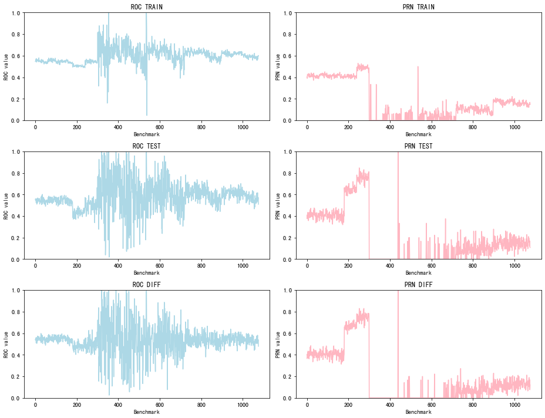

```python
show_all3(roc_train_knn, roc_test_knn, roc_diff_knn, prn_train_knn, prn_test_knn, prn_diff_knn)
```

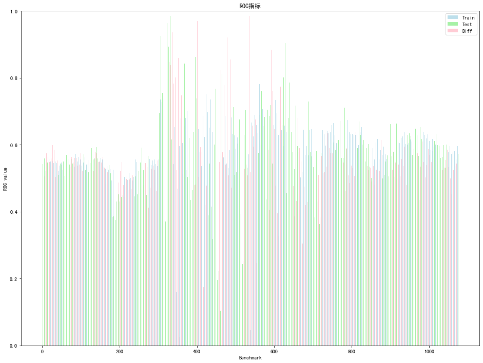

```python
show_roc3(roc_train_knn, roc_test_knn, roc_diff_knn)
```

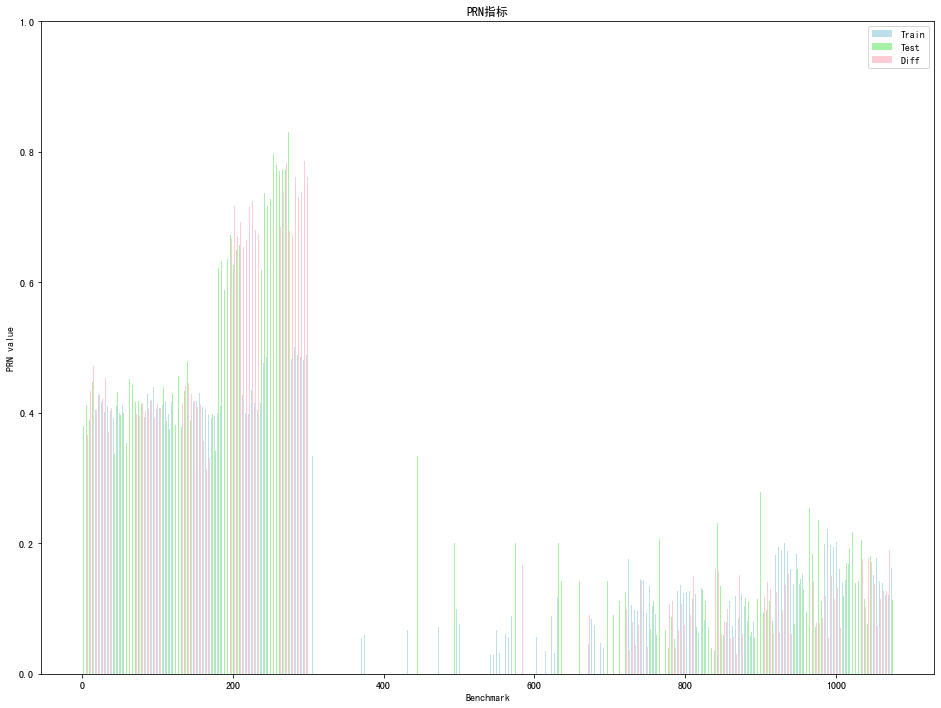

```python
show_prn3(prn_train_knn, prn_test_knn, prn_diff_knn)
```

#### avg KNN

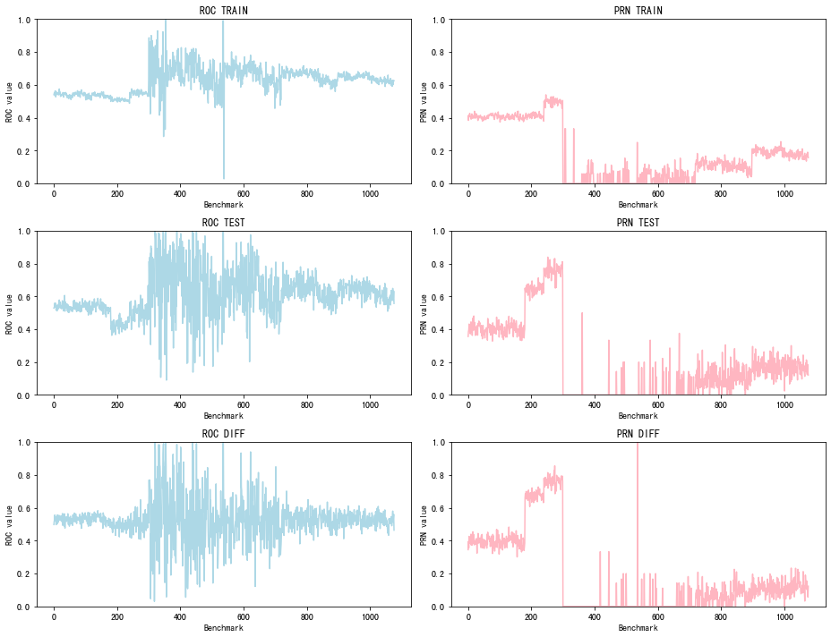

```python
show_all3(roc_train_avgknn, roc_test_avgknn, roc_diff_avgknn, prn_train_avgknn, prn_test_avgknn, prn_diff_avgknn)
```

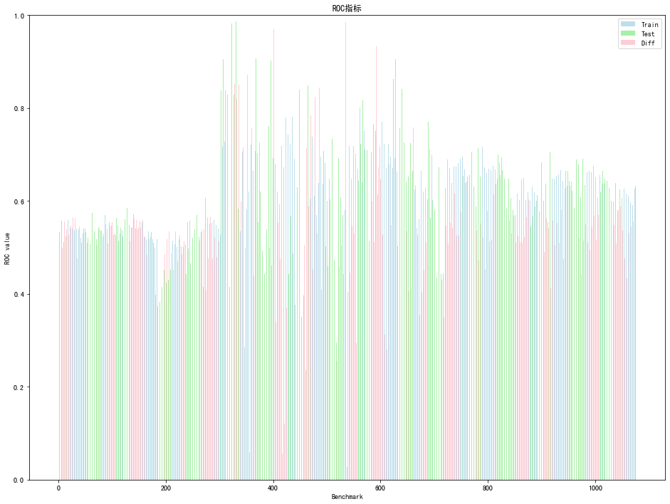

```python
show_roc3(roc_train_avgknn, roc_test_avgknn, roc_diff_avgknn)
```

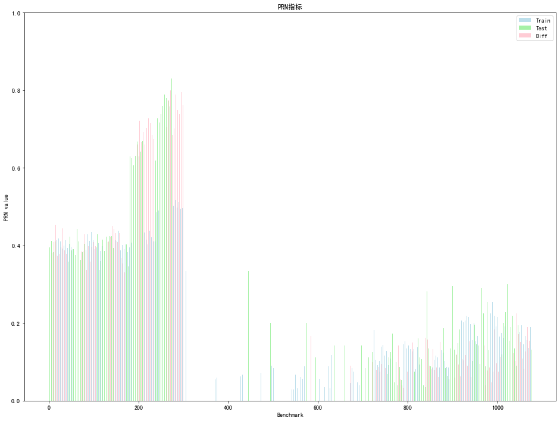

```python
show_prn3(prn_train_avgknn, prn_test_avgknn, prn_diff_avgknn)
```

#### PCA

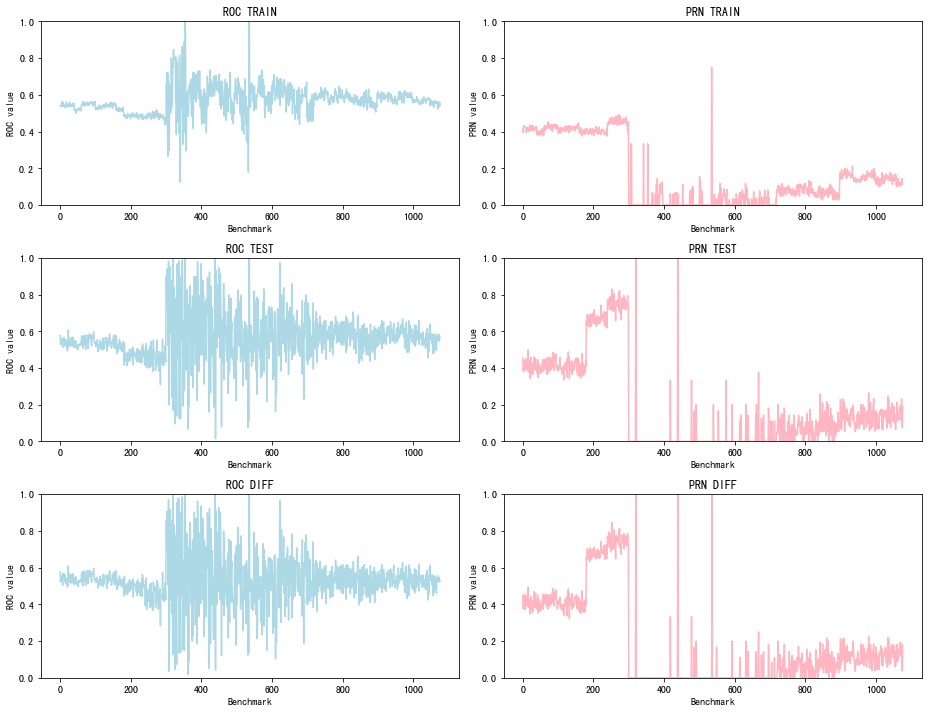

```python
show_all3(roc_train_pca, roc_test_pca, roc_diff_pca, prn_train_pca, prn_test_pca, prn_diff_pca)
```

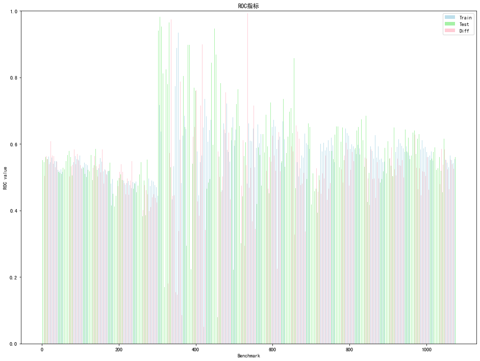

```python
show_roc3(roc_train_pca, roc_test_pca, roc_diff_pca)
```

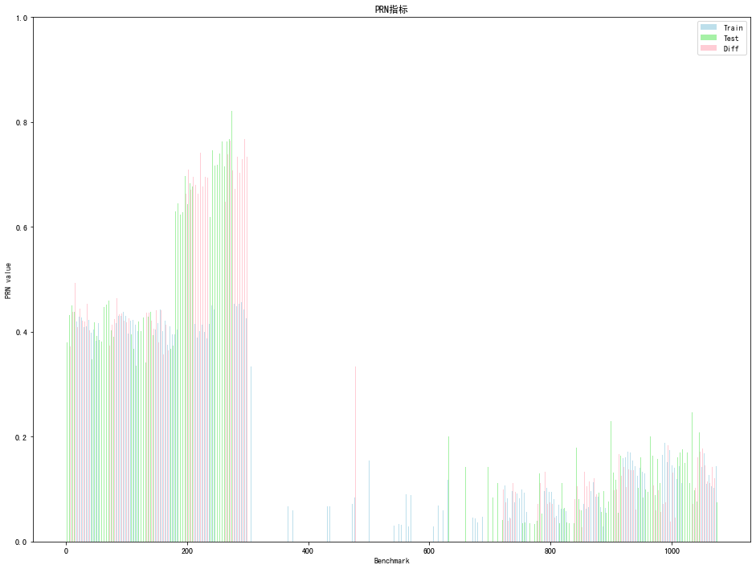

```python
show_prn3(prn_train_pca, prn_test_pca, prn_diff_pca)
```

#### MCD

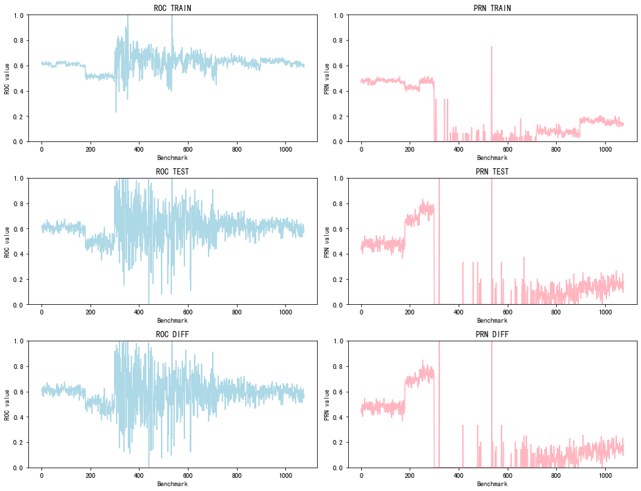

```python
show_all3(roc_train_mcd, roc_test_mcd, roc_diff_mcd, prn_train_mcd, prn_test_mcd, prn_diff_mcd)
```

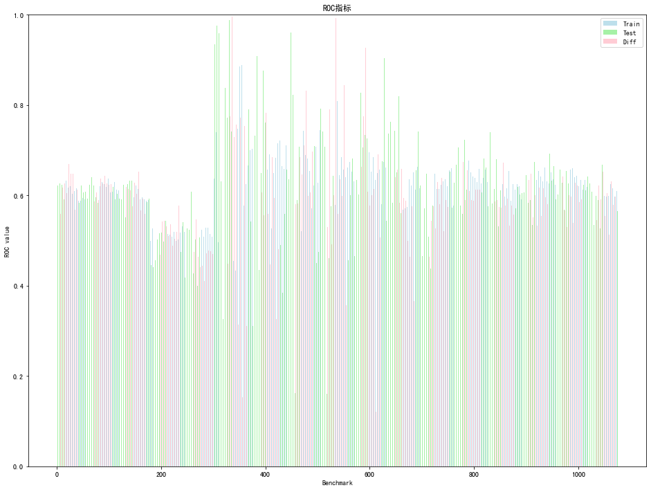

```python
show_roc3(roc_train_mcd, roc_test_mcd, roc_diff_mcd)
```

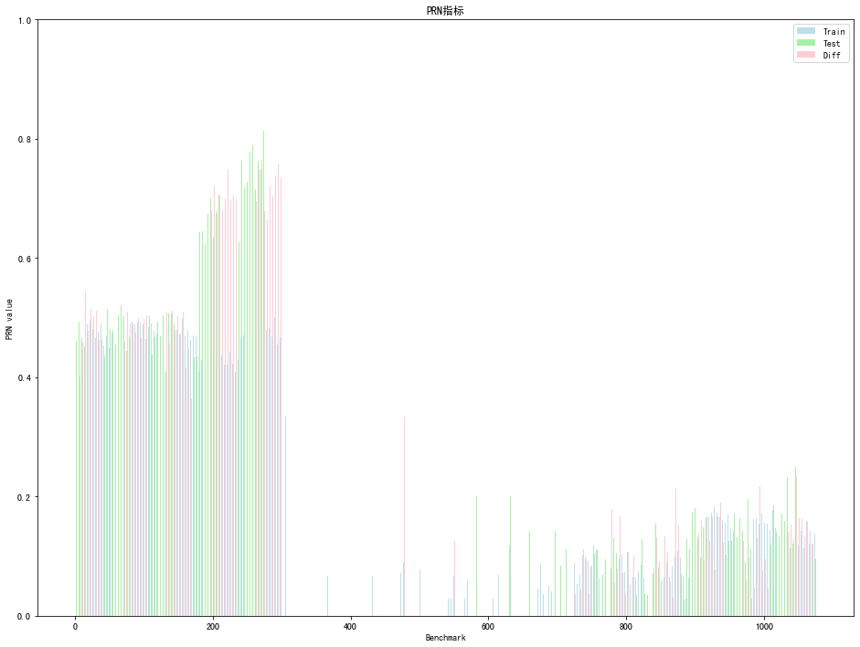

```python
show_prn3(prn_train_mcd, prn_test_mcd, prn_diff_mcd)
```

#### CBLOF

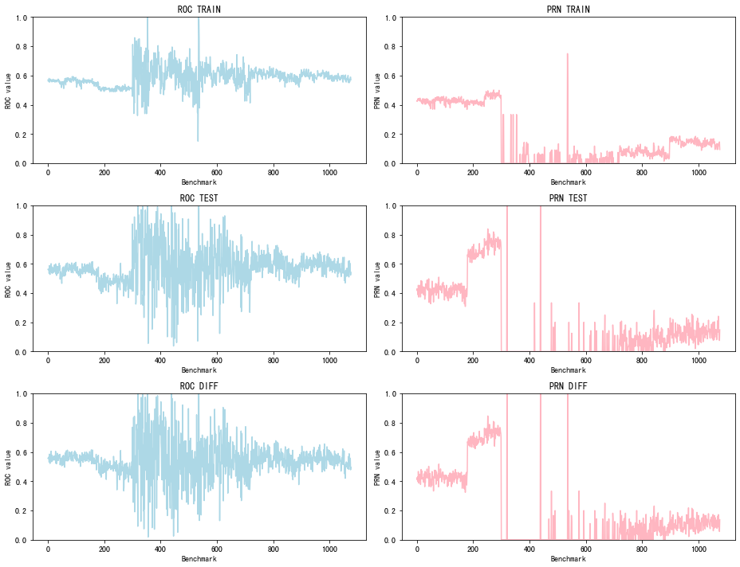

```python
show_all3(roc_train_cblof, roc_test_cblof, roc_diff_cblof, prn_train_cblof, prn_test_cblof, prn_diff_cblof)
```

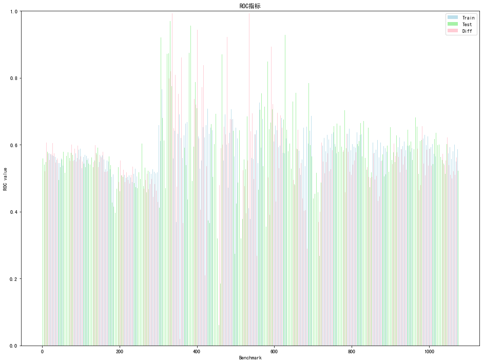

```python
show_roc3(roc_train_cblof, roc_test_cblof, roc_diff_cblof)
```

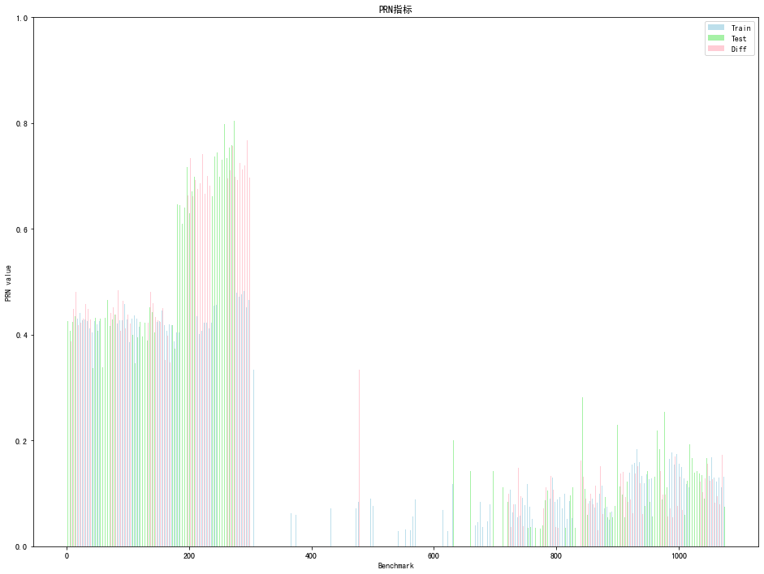

```python
show_prn3(prn_train_cblof, prn_test_cblof, prn_diff_cblof)
```

#### FB

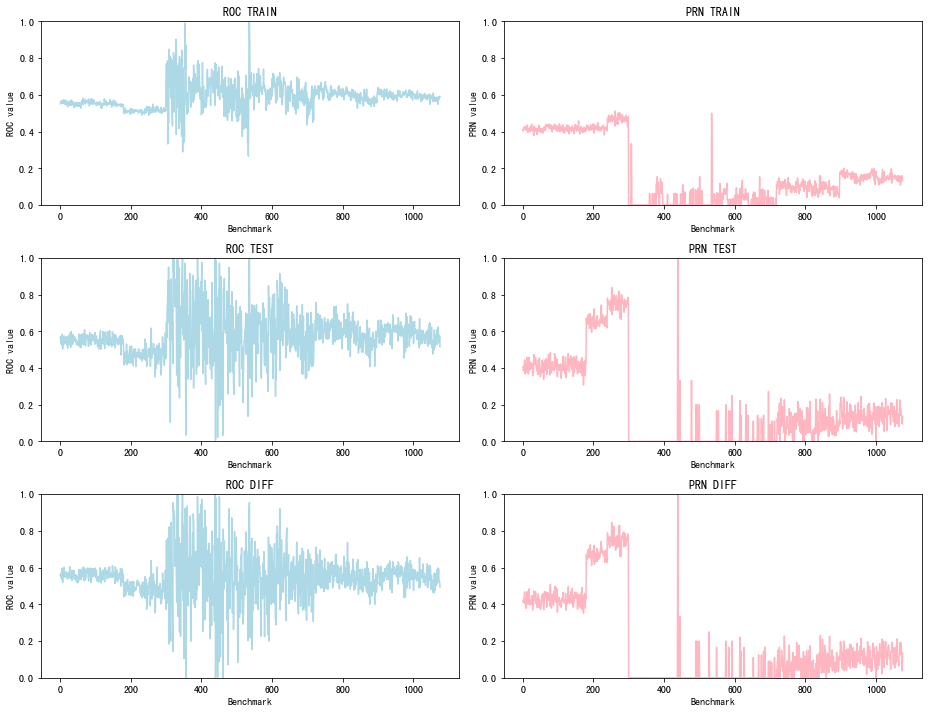

```python
show_all3(roc_train_fb, roc_test_fb, roc_diff_fb, prn_train_fb, prn_test_fb, prn_diff_fb)
```

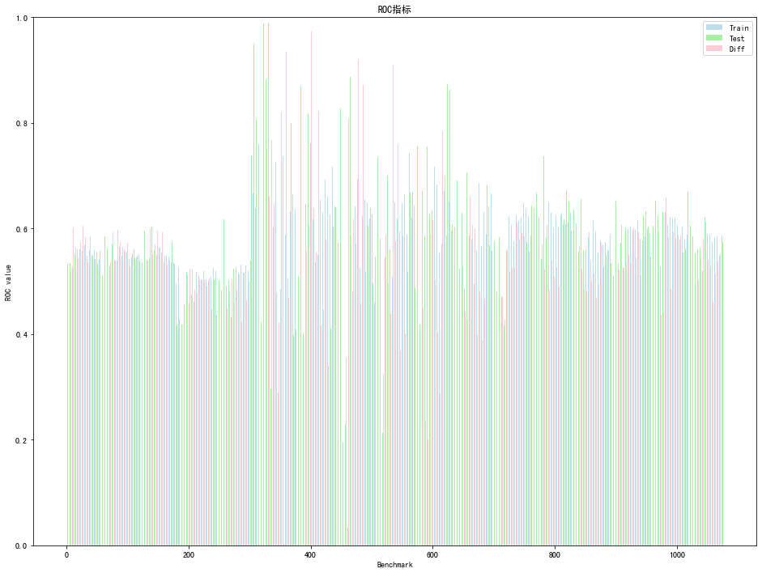

```python
show_roc3(roc_train_fb, roc_test_fb, roc_diff_fb)
```

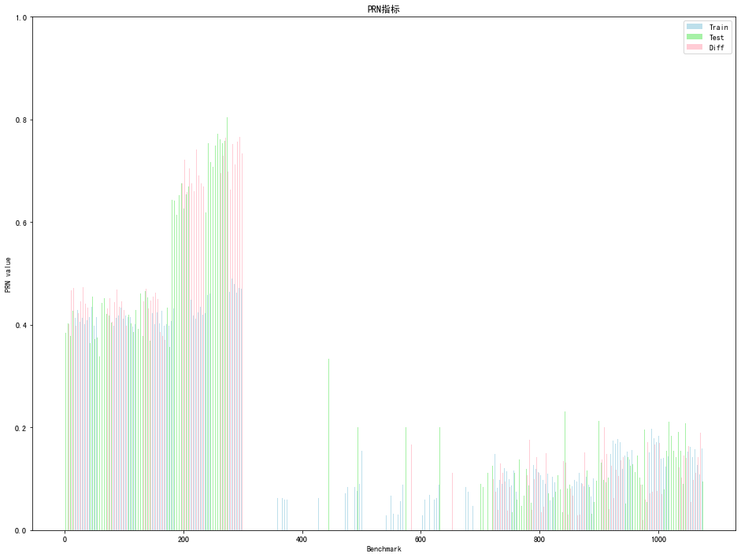

```python
show_prn3(prn_train_fb, prn_test_fb, prn_diff_fb)
```

#### HBOS

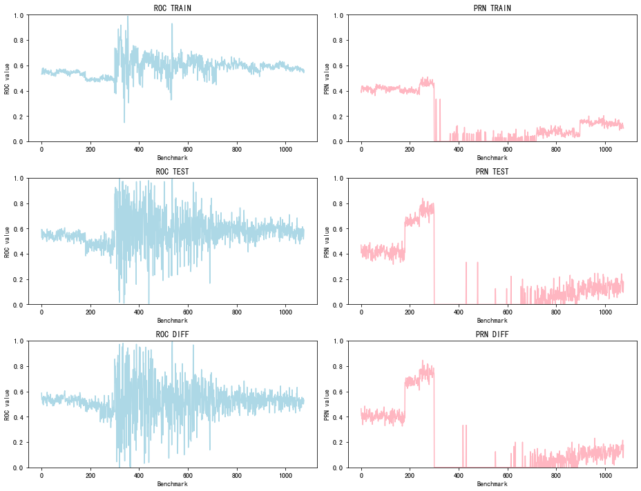

```python
show_all3(roc_train_hbos, roc_test_hbos, roc_diff_hbos, prn_train_hbos, prn_test_hbos, prn_diff_hbos)
```

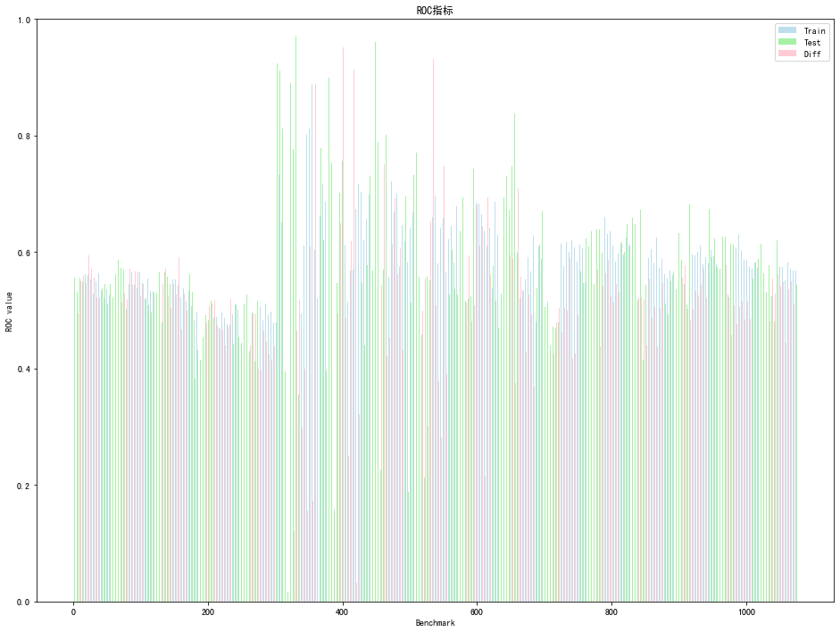

```python
show_roc3(roc_train_hbos, roc_test_hbos, roc_diff_hbos)
```

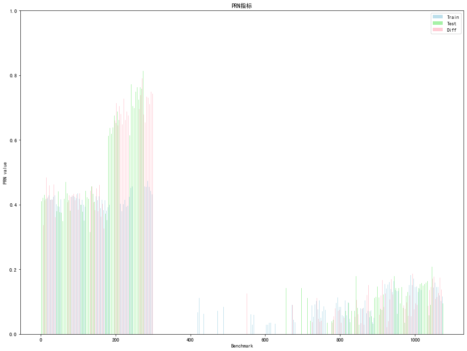

```python
show_prn3(prn_train_hbos, prn_test_hbos, prn_diff_hbos)
```

#### ISOF

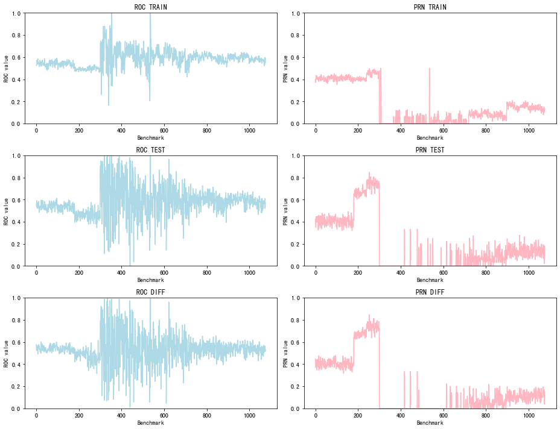

```python
show_all3(roc_train_isof, roc_test_isof, roc_diff_isof, prn_train_isof, prn_test_isof, prn_diff_isof)
```

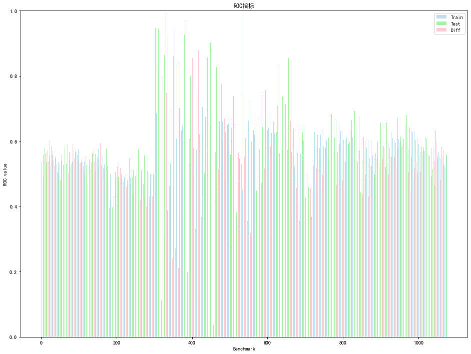

```python
show_roc3(roc_train_isof, roc_test_isof, roc_diff_isof)
```

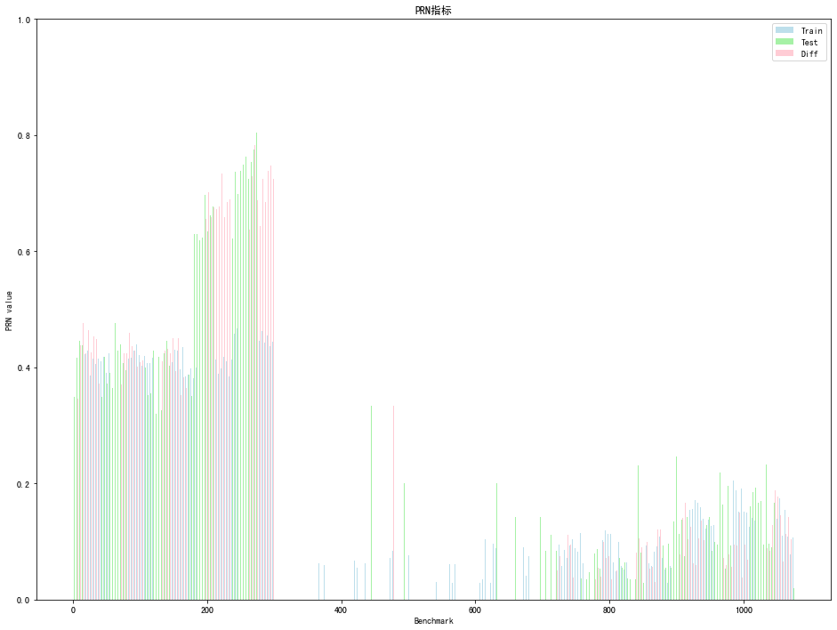

```python
show_prn3(prn_train_isof, prn_test_isof, prn_diff_isof)
```